# take home exam

TAEK YUN LEE

2018/9/09

```r
if(!require(ggplot2)){install.packages("ggplot2"); library(ggplot2)}
dat<- read.csv('C:/Users/renz/Desktop/Final/mobility.csv')
```

# 1-a

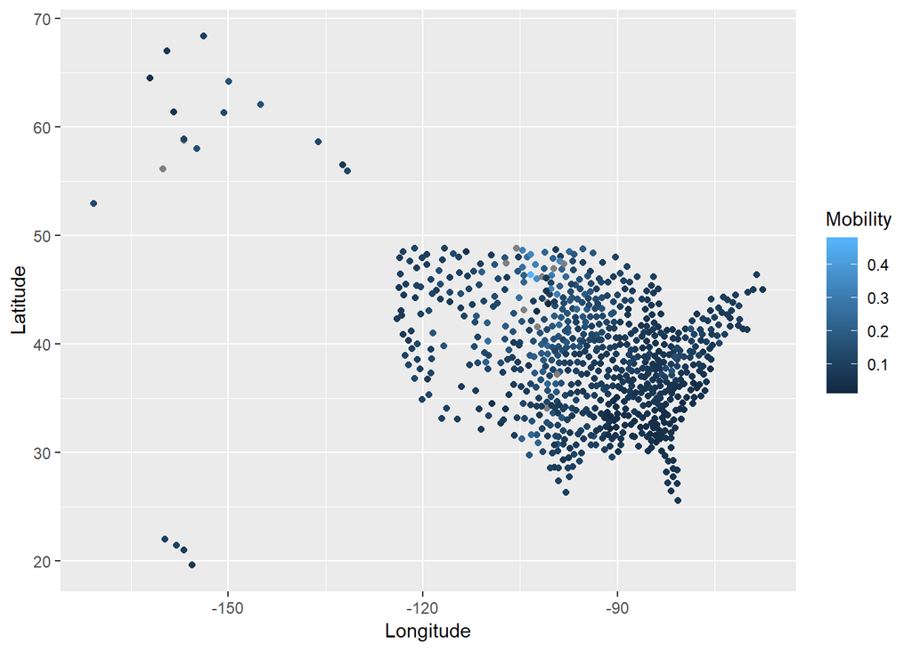

```r
ggplot(data = dat, aes(x = Longitude, y = Latitude , col = Mobility)) + geom_point()
```

지리적으로 경제적 이동성을 봤을때 미국 동부나 서부보다는 중부에서 상대적으로 경제적 이동성이높은것으로 보인다.

# 1-b

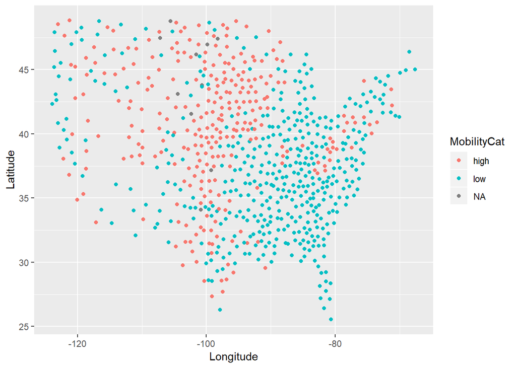

```r
newdat = dat[(dat$State != 'AK') & (dat$State != 'HI'), ]
newdat$MobilityCat <- 'NA'
newdat$MobilityCat <- ifelse(newdat$Mobility>0.1, 'high', 'low')
ggplot(data = newdat, aes(x = Longitude, y = Latitude , col = MobilityCat)) + geom_point()
```

MobilityCat 이라는 새로운 변수를 만들고 그것을 기준으로 plotting을 한 결과 바로위의 그래프보다 경제적이동성이 동부나 서부보다 중부근처에서 높은것이 뚜렷히 보인다.

# 2

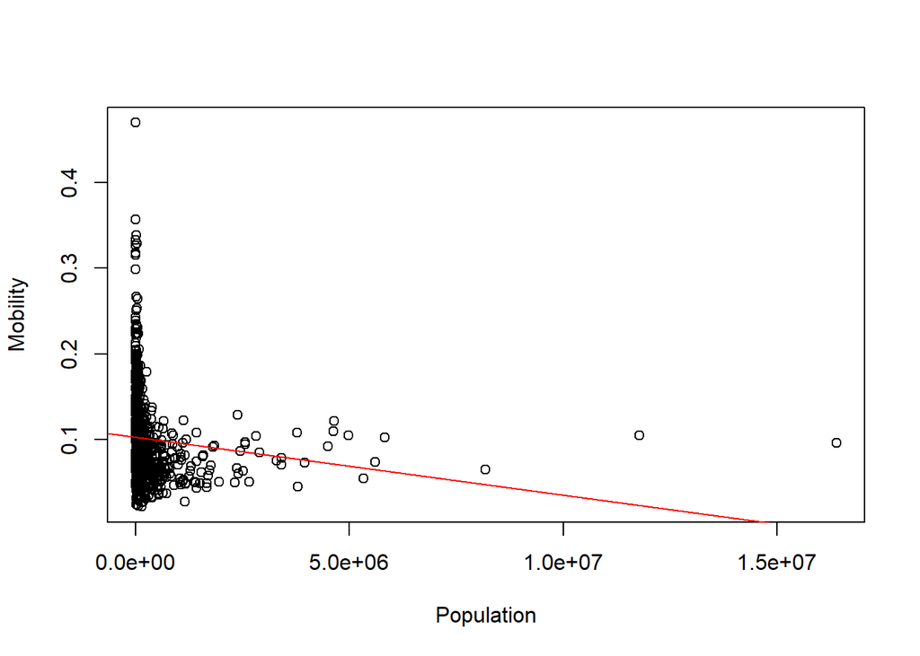

```r
attach(dat)
fit1 <- lm( Mobility ~ Population , data = dat )
plot(Population, Mobility )
abline(fit1 , col ='red')
```

```r
#install.packages('knitr')
#install.packages('kableExtra')
library(knitr)
library(kableExtra)
kable(as.data.frame(summary(fit1)[4]), digits=30) %>% kable_styling(bootstrap_options = c("striped", "condensed"))
```

|  | coefficients.Estimate | coefficients.Std..Error | coefficients.t.value | coefficients.Pr…t.. |
| --- | --- | --- | --- | --- |
| (Intercept) | 1.030221e-01 | 2.059279e-03 | 50.028261 | 0.0000000000 |
| Population | -6.732228e-09 | 1.834666e-09 | -3.669457 | 0.0002608342 |

population에 대한 계수는 -6.732228e-09과 같이 나왔고 인구가 많아 질수록 경제적이동성이 낮아지는 성향이 있으나 이 모델에 대한 설명력은 0.01818정도로 굉장히 낮다.

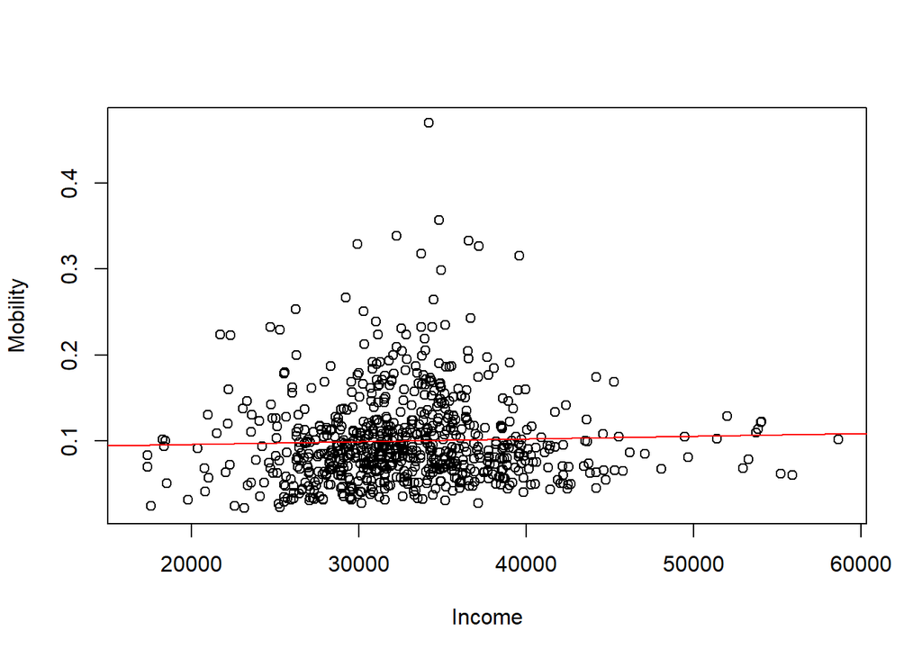

```r
fit2 <- lm( Mobility ~ Income , data = dat )
plot(Income, Mobility )
abline(fit2 , col ='red')
```

```r
kable(as.data.frame(summary(fit2)[4]), digits=30) %>% kable_styling(bootstrap_options = c("striped", "condensed"))
```

|  | coefficients.Estimate | coefficients.Std..Error | coefficients.t.value | coefficients.Pr…t.. |
| --- | --- | --- | --- | --- |
| (Intercept) | 9.024633e-02 | 1.133468e-02 | 7.9619628 | 6.518812e-15 |
| Income | 3.094097e-07 | 3.394621e-07 | 0.9114705 | 3.623496e-01 |

income에대한 계수는 3.094097e-07이고 소득이 많을수록 경제적이동성이 미약하게 증가하는 경향을 보이지만 역시 설명력은 낮은 편이다.

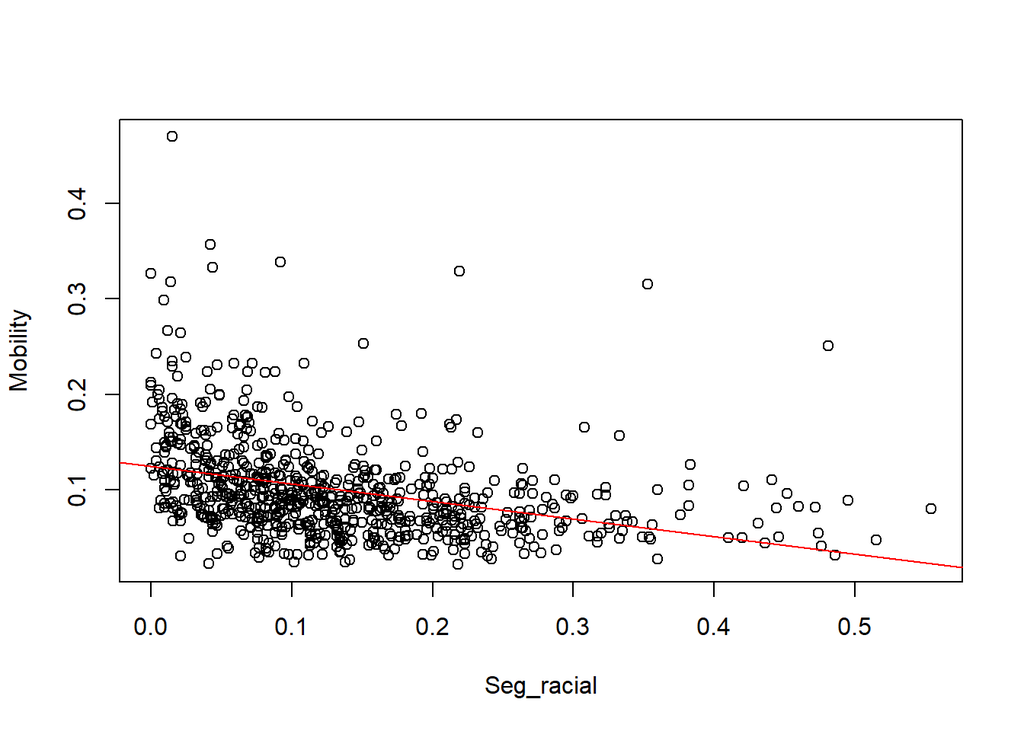

```r
fit3 <- lm( Mobility ~ Seg_racial , data = dat )
plot(Seg_racial, Mobility )
abline(fit3 , col ='red')
```

```r
kable(as.data.frame(summary(fit3)[4]), digits=30) %>% kable_styling(bootstrap_options = c("striped", "condensed"))
```

|  | coefficients.Estimate | coefficients.Std..Error | coefficients.t.value | coefficients.Pr…t.. |
| --- | --- | --- | --- | --- |
| (Intercept) | 0.1246090 | 0.003037536 | 41.023043 | 0.000000e+00 |
| Seg_racial | -0.1835019 | 0.018393268 | -9.976578 | 4.680267e-22 |

Seg_racial에 대한 회귀계수는 -0.1835019이며 Seg_racial이 증가할수록 경제적 이동성이 낮아지는 경향이 있다.

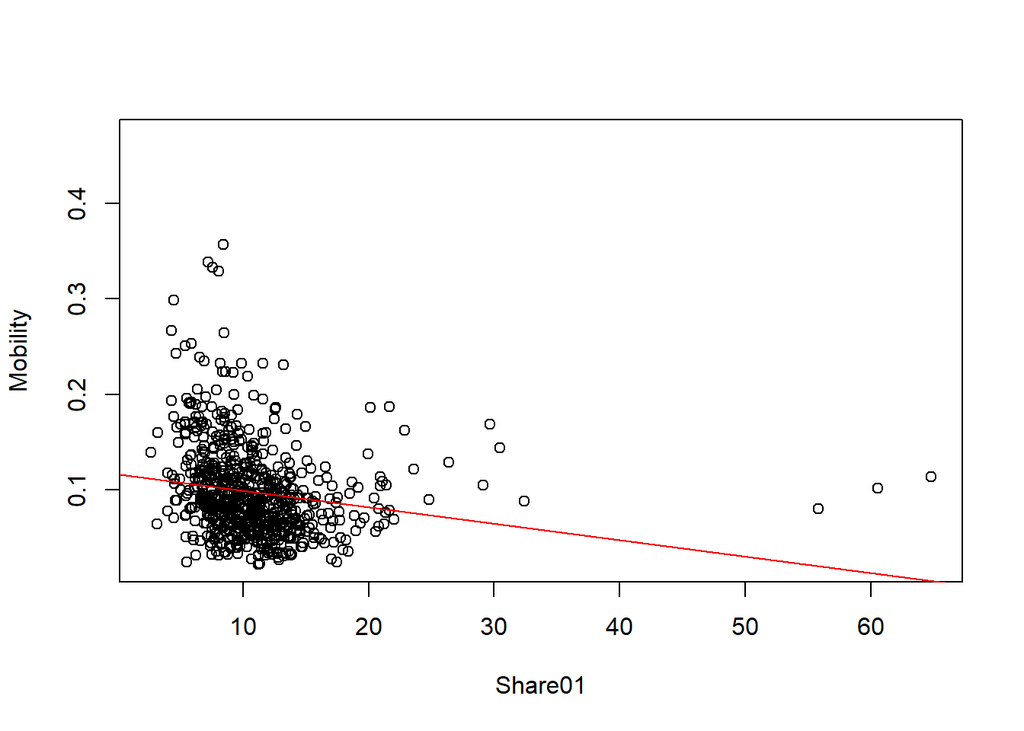

```r
fit4 <- lm( Mobility ~ Share01 , data = dat )
plot(Share01, Mobility )
abline(fit4 , col ='red')
```

```r
kable(as.data.frame(summary(fit4)[4]), digits=30) %>% kable_styling(bootstrap_options = c("striped", "condensed"))
```

|  | coefficients.Estimate | coefficients.Std..Error | coefficients.t.value | coefficients.Pr…t.. |
| --- | --- | --- | --- | --- |
| (Intercept) | 0.116250913 | 0.0042073697 | 27.630306 | 0.000000e+00 |
| Share01 | -0.001718199 | 0.0003518374 | -4.883502 | 1.289615e-06 |

Share01에 대한 회귀계수는 -0.001718199이며 share01이 미약하게 낮아지는 경향이 있다. 설명력은 낮다.

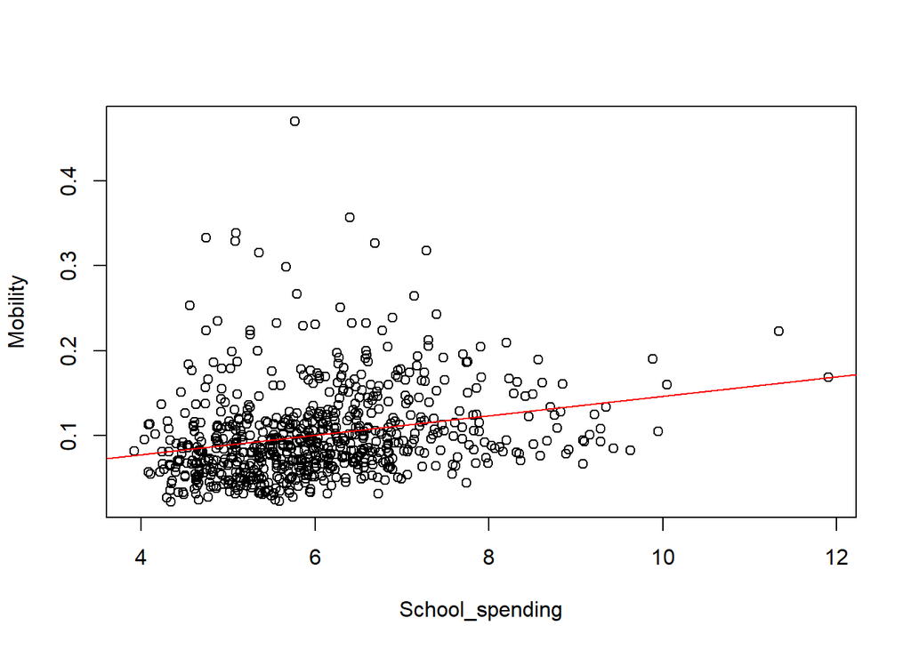

```r
fit5 <- lm( Mobility ~ School_spending , data = dat )
plot(School_spending, Mobility )
abline(fit5 , col ='red')
```

```r
kable(as.data.frame(summary(fit5)[4]), digits=30) %>% kable_styling(bootstrap_options = c("striped", "condensed"))
```

|  | coefficients.Estimate | coefficients.Std..Error | coefficients.t.value | coefficients.Pr…t.. |
| --- | --- | --- | --- | --- |
| (Intercept) | 0.03167886 | 0.010170102 | 3.114901 | 1.913271e-03 |
| School_spending | 0.01146429 | 0.001662318 | 6.896569 | 1.169495e-11 |

School_spending에 대한 회귀계수는 0.01146429정도이며 전체적으로 School_spending이 늘어날수록 경제적이동성도 증가하는 편이다.

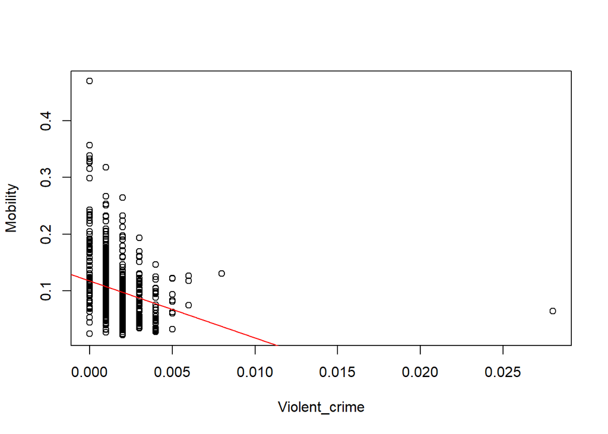

```r
fit6 <- lm( Mobility ~ Violent_crime , data = dat )
plot(Violent_crime, Mobility )
abline(fit6 , col ='red')
```

```r
kable(as.data.frame(summary(fit6)[4]), digits=30) %>% kable_styling(bootstrap_options = c("striped", "condensed"))
```

|  | coefficients.Estimate | coefficients.Std..Error | coefficients.t.value | coefficients.Pr…t.. |
| --- | --- | --- | --- | --- |
| (Intercept) | 0.1176149 | 0.002834322 | 41.496660 | 0.000000e+00 |
| Violent_crime | -10.0505704 | 1.294376610 | -7.764796 | 2.909666e-14 |

Violent_crime에 대한 회귀계수는 -10.0505704 정도 되며 Violent_crime이 높아질수록 경제적이동성이 낮아지는 경향이 있다. 설명력은 낮다.

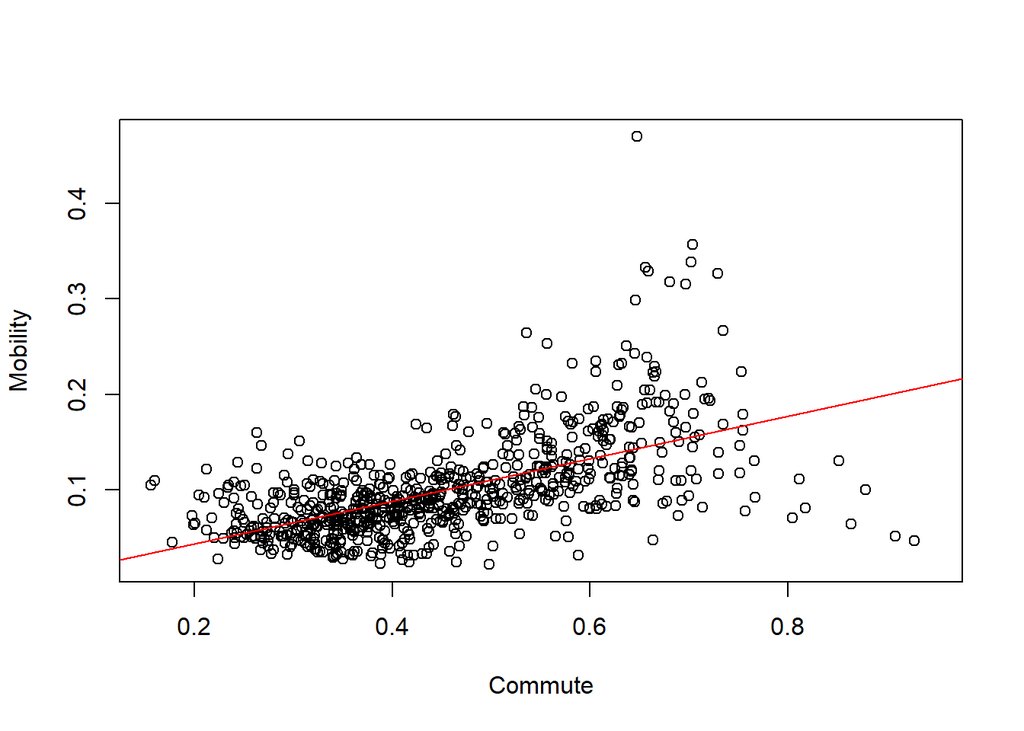

```r
fit7 <- lm( Mobility ~ Commute , data = dat )
plot(Commute, Mobility )
abline(fit7 , col ='red')
```

```r
kable(as.data.frame(summary(fit7)[4]), digits=30) %>% kable_styling(bootstrap_options = c("striped", "condensed"))
```

|  | coefficients.Estimate | coefficients.Std..Error | coefficients.t.value | coefficients.Pr…t.. |
| --- | --- | --- | --- | --- |
| (Intercept) | -0.0001972589 | 0.005336157 | -0.03696647 | 0.9705219 |
| Commute | 0.2218695292 | 0.011242247 | 19.73533719 | 0.0000000 |

Commute에대한 회귀계수는 0.2218695292이며 Commute이 증가할수록 경제적 이동성이 높아지는 경향이 있다.

# 3-a

```r
linear.fit <- lm( Mobility ~., data = dat[,-c(1,2,20,21)] )
summary(linear.fit)
```

```
##
## Call:
## lm(formula = Mobility ~ ., data = dat[, -c(1, 2, 20, 21)])
##
## Residuals:
##       Min        1Q    Median        3Q       Max
## -0.079902 -0.008685 -0.000078  0.008364  0.105604
##
## Coefficients:
##                             Estimate Std. Error t value Pr(>|t|)
## (Intercept)                7.439e-02  8.962e-02   0.830 0.407077
## StateAR                   -8.012e-03  9.102e-03  -0.880 0.379328
## StateAZ                   -1.429e-02  2.821e-02  -0.507 0.612818
## StateCA                   -3.351e-02  2.770e-02  -1.210 0.227263
## StateDC                    2.861e-03  2.636e-02   0.109 0.913639
## StateDE                   -1.126e-02  2.171e-02  -0.519 0.604170
## StateFL                   -2.830e-02  2.328e-02  -1.216 0.224997
## StateGA                   -2.634e-02  9.207e-03  -2.861 0.004493 **
## StateIA                   -2.812e-03  1.475e-02  -0.191 0.848880
## StateID                   -6.836e-02  2.309e-02  -2.960 0.003295 **
## StateIL                   -2.446e-02  1.530e-02  -1.599 0.110862
## StateIN                    3.468e-03  1.602e-02   0.216 0.828769
## StateKS                   -3.635e-02  1.362e-02  -2.669 0.007981 **
## StateKY                   -1.018e-02  1.053e-02  -0.967 0.334307
## StateLA                   -5.387e-03  1.133e-02  -0.476 0.634726
## StateMA                   -1.353e-02  3.010e-02  -0.449 0.653485
## StateMD                   -1.324e-02  1.836e-02  -0.721 0.471321
## StateME                   -6.660e-03  2.461e-02  -0.271 0.786847
## StateMN                   -8.123e-04  1.841e-02  -0.044 0.964839
## StateMO                   -2.054e-02  1.106e-02  -1.856 0.064271 .
## StateMS                   -7.687e-03  8.524e-03  -0.902 0.367822
## StateMT                   -2.685e-02  2.112e-02  -1.271 0.204648
## StateNC                   -2.601e-02  1.124e-02  -2.314 0.021270 *
## StateND                    5.285e-02  1.926e-02   2.744 0.006386 **
## StateNE                   -1.290e-02  1.539e-02  -0.838 0.402500
## StateNH                   -2.242e-03  2.518e-02  -0.089 0.929109
## StateNM                   -1.971e-02  1.478e-02  -1.334 0.183173
## StateNV                   -3.423e-02  2.623e-02  -1.305 0.192719
## StateNY                   -9.077e-03  2.012e-02  -0.451 0.652141
## StateOH                   -2.803e-02  1.708e-02  -1.641 0.101705
```

[output cut: 43 more lines]

```
## Social_capital            -6.020e-03  2.760e-03  -2.182 0.029836 *
## Religious                  7.131e-03  1.397e-02   0.510 0.610075
## Violent_crime             -2.788e-01  1.664e+00  -0.168 0.867056
## Single_mothers            -2.675e-01  8.963e-02  -2.985 0.003047 **
## Divorced                  -2.100e-01  1.676e-01  -1.253 0.210990
## Married                   -3.409e-02  6.466e-02  -0.527 0.598433
## Longitude                 -9.199e-04  6.184e-04  -1.488 0.137804
## Latitude                   2.442e-04  1.031e-03   0.237 0.812936
## ---
## Signif. codes:  0 '***' 0.001 '**' 0.01 '*' 0.05 '.' 0.1 ' ' 1
##
## Residual standard error: 0.01987 on 337 degrees of freedom
##   (323 observations deleted due to missingness)
## Multiple R-squared:  0.8357, Adjusted R-squared:  0.7967
## F-statistic: 21.43 on 80 and 337 DF,  p-value: < 2.2e-16
```

# 3-b

ID라는 변수를 가지고 회귀분석을 시행하였을 때 유의확률이 클뿐만 아니라 ID는 경제적이동성과 상관관계가 없다고 판단되기때문에 ID라는 변수는 제외합니다.

# 3-c

설명 변수 중에서 ‘ID’,‘Name’,‘progressivity’, ‘EITC’ 를 우선적으로 제거 하였는데 우선 ’ID’와’Name’는 유의하지 않은 변수들이었으며 ’progressivity’와 ’EITC’는 회귀분석 결과에 NA값을 유발하므로 제외하였습니다. 뒤에 3-e번 문제 부터는 전체 변수를 가지고 회귀적합 결과 유의확률이 0.05 이하인 변수들만 가지고 시행하였습니다.

# 3-d

population에대한 회귀계수는 -6.732228e-09에서 1.147e-09으로 바뀌었다.

Income에대한 회귀계수는 3.094097e-07에서 1.081e-06으로 바뀌었다.

Seg_racial에대한 회귀계수는 -0.1835019에서 -6.356e-02으로 바뀌었다.

share01에대한 회귀계수는 -0.001718199에서 -2.217e-02으오 바뀌었다.

School_spending에대한 회귀계수는 0.01146429에서 -6.120e-04으로 바뀌었다.

Violent_crime에 대한 회귀계수는 -10.0505704에서 -2.788e-01으로 바뀌었다.

Commute에대한 회귀계수는 0.2218695292에서 5.913e-02으로 바뀌었다.

population, School_spending에 대한 계수의 부호가 바뀌었습니다.

# 3-e

```r
#coeffs[coeffs[,4] < 0.05,]
#install.packages('car')
#vif(linear.fit)
#linear.fit
library(car)
linear.fit <- lm(Mobility ~ Black +  Seg_racial +Seg_poverty +Commute  +Middle_class+ Manufacturing + Migration_out + Foreign_born + Social_capital+ Single_mothers)
vif(linear.fit)
```

```
##          Black     Seg_racial    Seg_poverty        Commute   Middle_class
##       3.108821       1.638071       2.745458       2.971986       4.339077
##  Manufacturing  Migration_out   Foreign_born Social_capital Single_mothers
##       1.581508       1.562930       1.744865       2.561305       4.183750
```

위의 변수들을 가지고서 다중회귀분석을 시행하고 vif값을 살펴본결과 10을 넘는 vif값은 없으므로 다중공선성은 의심되지 않지만 다중 공선성을 피하기 위해서는 각 변수들간의 상관계수행렬을 만들어 살펴보거나 vif값이 10이 넘는 것들을 제거하면된다. 또한 비슷한 성질을 지닌 변수들을 넣지 않는 방법도 있다.

# 4-a

```r
sum(is.na(dat$Tuition))
```

```
## [1] 161
```

```r
sum(is.na(dat$Colleges))
```

```
## [1] 157
```

```r
sum(is.na(dat$Graduation))
```

```
## [1] 160
```

Tuition은 NA값이 161개 Colleges는 NA값이 157개 Graduation은 NA값이 160개이다.

# 4-b

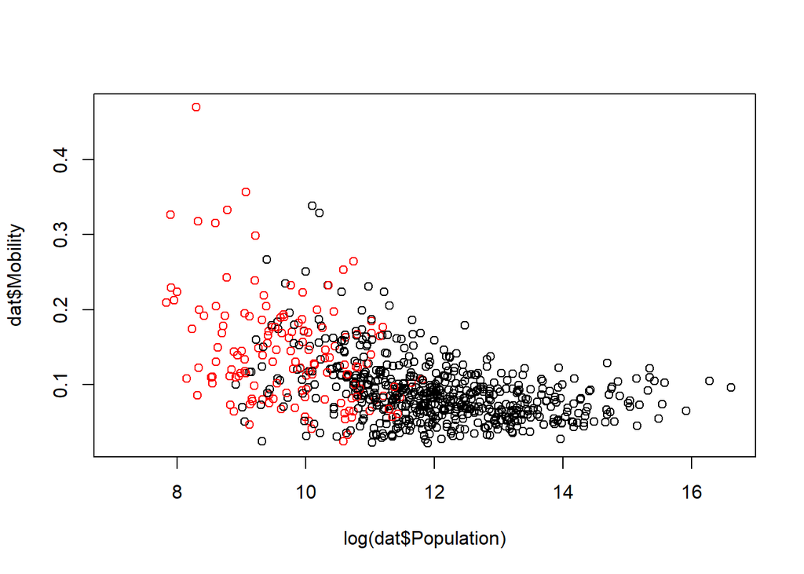

```r
plot(log(dat$Population), dat$Mobility ,
     col= ifelse( is.na(dat$Colleges)  , 'red'  , 'black' ))
```

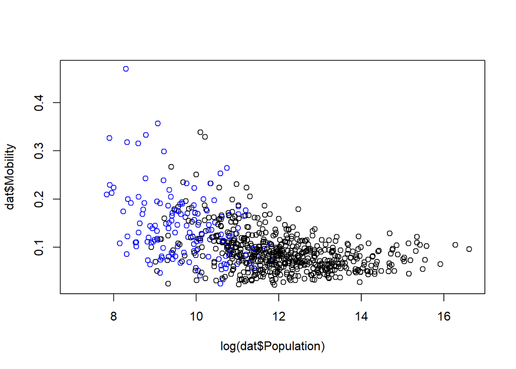

```r
plot(log(dat$Population), dat$Mobility ,
     col= ifelse( is.na(dat$Tuition)  , 'blue'  , 'black' ))
```

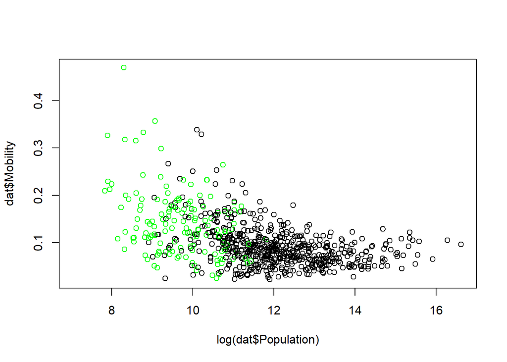

```r
plot(log(dat$Population), dat$Mobility ,
     col= ifelse( is.na(dat$Graduation)  , 'green'  , 'black' ))
```

log(dat$Population) 값이 11이하인 점들에 한해서 NA값을 가지는 경향이 보인다.

# 4-c

```r
newdat2 <- dat
newdat2$HE <-'NA'
newdat2$Colleges[is.na(newdat2$Colleges)] <-0
newdat2$Tuition[is.na(newdat2$Tuition)] <-0
newdat2$Graduation[is.na(newdat2$Graduation)] <-0

newdat2$HE <- ifelse(newdat2$Colleges >0 | newdat2$Tuition >0 | newdat2$Graduation>0,'TRUE','FALSE')
```

# 5

```r
linear.fit <- lm(Mobility ~ Black +  Seg_racial +Seg_poverty +Commute  +Middle_class+ Manufacturing +  Foreign_born + Social_capital+ Single_mothers +Violent_crime  , data = newdat2)
summary(linear.fit)
```

```
##
## Call:
## lm(formula = Mobility ~ Black + Seg_racial + Seg_poverty + Commute +
##     Middle_class + Manufacturing + Foreign_born + Social_capital +
##     Single_mothers + Violent_crime, data = newdat2)
##
## Residuals:
##       Min        1Q    Median        3Q       Max
## -0.087127 -0.015694 -0.001795  0.011917  0.181614
##
## Coefficients:
##                 Estimate Std. Error t value Pr(>|t|)
## (Intercept)     0.116911   0.021123   5.535 4.51e-08 ***
## Black           0.098063   0.015532   6.314 5.02e-10 ***
## Seg_racial     -0.003126   0.014003  -0.223 0.823418
## Seg_poverty    -0.152745   0.060654  -2.518 0.012030 *
## Commute         0.083522   0.014992   5.571 3.70e-08 ***
## Middle_class    0.117298   0.028881   4.061 5.47e-05 ***
## Manufacturing  -0.159217   0.017464  -9.117  < 2e-16 ***
## Foreign_born    0.113251   0.030605   3.700 0.000233 ***
## Social_capital  0.002409   0.001355   1.777 0.076020 .
## Single_mothers -0.494962   0.043940 -11.264  < 2e-16 ***
## Violent_crime  -1.725330   1.289477  -1.338 0.181358
## ---
## Signif. codes:  0 '***' 0.001 '**' 0.01 '*' 0.05 '.' 0.1 ' ' 1
##
## Residual standard error: 0.0286 on 655 degrees of freedom
##   (75 observations deleted due to missingness)
## Multiple R-squared:  0.6618, Adjusted R-squared:  0.6567
## F-statistic: 128.2 on 10 and 655 DF,  p-value: < 2.2e-16
```

4번에서 도출된 HE라는 변수를 이용해봤으나 설명력에 차이가 없어서 제외하였고 위에 보이는 변수들만을 이용하여 회귀분석을 수행하였다. 또한 Migration_out도 마찬가지 이유로 제외하였다.

# 6

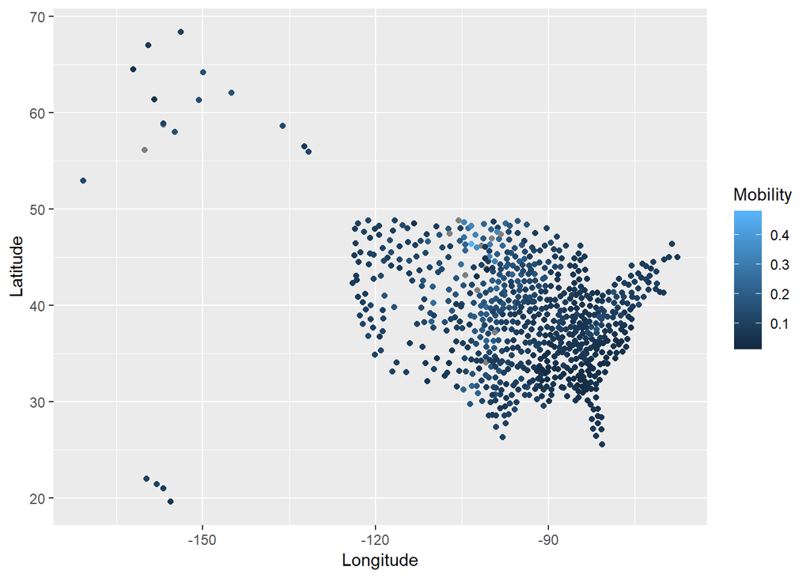

```r
newdat2$Middle_class[is.na(newdat2$Middle_class)] <-0
newdat2$Social_capital[is.na(newdat2$Social_capital)] <-0

newdat2$pred_Mobility <-'NA'
newdat2$pred_Mobility <- predict(linear.fit , newdata =newdat2)

library(gridExtra)
par(mfrow =c(1,2))
ggplot(data = dat, aes(x = Longitude, y = Latitude , col = Mobility)) + geom_point()
```

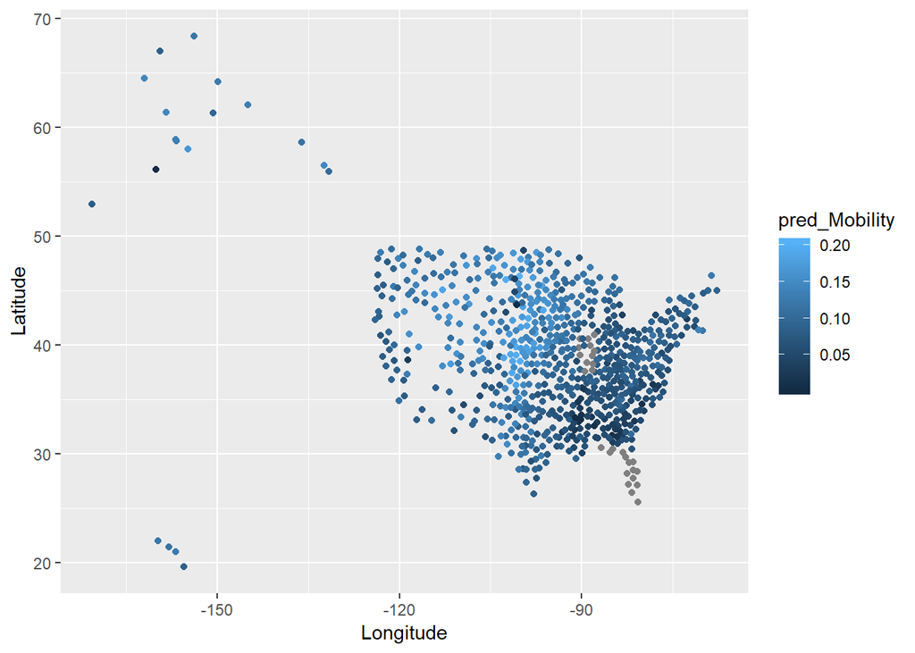

```r
ggplot(data = newdat2, aes(x = Longitude, y = Latitude , col = pred_Mobility)) + geom_point()
```

```r
#grid.arrange(p1,p2,ncol = 2, nrow =1, widths=c(10,10) )
```

실제 그래프와 예측된 그래프를 비교해보면 예측된 그래프의 예측 수치들이 실제그래프의 경제적이동성 수치를 완벽하게 가까이 예측하지는 못한다. 하지만 비슷한 추세를 보인다.

# 7-a

```r
paste0('실제값   ', newdat2[newdat2$Name == 'Pittsburgh'  , ]$Mobility)
```

```
## [1] "실제값   0.09514869"
```

```r
paste0('예측값   ', newdat2[newdat2$Name == 'Pittsburgh'  , ]$pred_Mobility)
```

```
## [1] "예측값   0.0768523961126035"
```

# 7-b

```r
newdat2$double_crime <-'NA'
newdat2$double_crime <- newdat2$Violent_crime*2

newdat2$half_crime <-'NA'
newdat2$half_crime <- newdat2$Violent_crime*0.5

double.fit <- lm(Mobility ~ Black +  Seg_racial +Seg_poverty +Commute  +Middle_class+ Manufacturing +  Foreign_born + Social_capital+ Single_mothers + double_crime , data = newdat2)

half.fit <- lm(Mobility ~ Black +  Seg_racial +Seg_poverty +Commute  +Middle_class+ Manufacturing +  Foreign_born + Social_capital+ Single_mothers + half_crime , data = newdat2)


newdat2$pred_double_crime <-'NA'
newdat2$pred_double_crime <- predict(double.fit , newdata = newdat2)

newdat2$pred_half_crime <-'NA'
newdat2$pred_half_crime <- predict(half.fit , newdata = newdat2)

newdat2[newdat2$Name == 'Pittsburgh'  , ]
```

```
##        ID       Name   Mobility State Population Urban Black Seg_racial
## 229 16300 Pittsburgh 0.09514869    PA    2561364     1 0.075      0.323
##     Seg_income Seg_poverty Seg_affluence Commute Income Gini Share01
## 229      0.081       0.069         0.089   0.287  38686 0.45  13.848
##     Gini_99 Middle_class Local_tax_rate Local_gov_spending Progressivity
## 229   0.312        0.533          0.025               2244             0
##     EITC School_spending Student_teacher_ratio Test_scores HS_dropout
## 229    0           8.199                  18.1       5.035      -0.01
##     Colleges Tuition Graduation Labor_force_participation Manufacturing
## 229    0.022    8789      0.092                     0.599         0.124
##     Chinese_imports Teenage_labor Migration_in Migration_out Foreign_born
## 229           0.556         0.004        0.007         0.011        0.025
##     Social_capital Religious Violent_crime Single_mothers Divorced Married
## 229          0.604     0.651         0.002          0.209    0.082   0.545
##     Longitude Latitude   HE pred_Mobility double_crime half_crime
## 229 -79.57613 40.56791 TRUE     0.0768524        0.004      0.001
##     pred_double_crime pred_half_crime
## 229        0.08201649      0.08201649
```

```r
newdat2[newdat2$Name == 'Pittsburgh'  , ]$pred_double_crime
```

```
## [1] 0.08201649
```

```r
newdat2[newdat2$Name == 'Pittsburgh'  , ]$pred_half_crime
```

```
## [1] 0.08201649
```

violent crime rate값을 두배를 한경우나 1/2한 경우나 예측된값에 있어서 차이가 없다.

# 7-c,d

```r
linear.fit <- lm(Mobility ~ Black +  Seg_racial +Seg_poverty +Commute  +Middle_class+ Manufacturing +  Foreign_born + Social_capital+ Single_mothers +Violent_crime , data = newdat2)

predict(linear.fit, newdata=data.frame(Black=0.075 ,Seg_racial=0.323 ,Seg_poverty=0.069 ,Commute=0.287  ,Middle_class=0.533, Manufacturing= 0.124 ,  Foreign_born=0.025 , Social_capital=0.604, Single_mothers=0.209 ,Violent_crime= 0.002), interval="confidence")
```

```
##          fit        lwr        upr
## 1 0.08201649 0.07530247 0.08873051
```

```r
predict(linear.fit, newdata=data.frame(Black=0.075 ,Seg_racial=0.323 ,Seg_poverty=0.069 ,Commute=0.287  ,Middle_class=0.533, Manufacturing= 0.124 ,  Foreign_born=0.025 , Social_capital=0.604, Single_mothers=0.209 ,Violent_crime= 0.002), interval="prediction")
```

```
##          fit        lwr       upr
## 1 0.08201649 0.01885935 0.1451736
```

confidence interval 과 prediction interval을 비교해 보면 prediction interval의 범위가 confidence interval에 비해 넓은 범위를 보인다.

# 8-a

```r
linear.fit <- lm(Mobility ~ Black +  Seg_racial +Seg_poverty +Commute  +Middle_class+ Manufacturing +  Foreign_born + Social_capital+ Single_mothers +Violent_crime , data = newdat2)
summary(linear.fit)
```

```
##
## Call:
## lm(formula = Mobility ~ Black + Seg_racial + Seg_poverty + Commute +
##     Middle_class + Manufacturing + Foreign_born + Social_capital +
##     Single_mothers + Violent_crime, data = newdat2)
##
## Residuals:
##       Min        1Q    Median        3Q       Max
## -0.129357 -0.016523 -0.002113  0.012570  0.234592
##
## Coefficients:
##                 Estimate Std. Error t value Pr(>|t|)
## (Intercept)     0.231032   0.013474  17.146  < 2e-16 ***
## Black           0.102344   0.016697   6.129 1.48e-09 ***
## Seg_racial      0.011298   0.015280   0.739  0.45992
## Seg_poverty    -0.164845   0.064866  -2.541  0.01126 *
## Commute         0.083366   0.014301   5.829 8.53e-09 ***
## Middle_class   -0.024150   0.011499  -2.100  0.03608 *
## Manufacturing  -0.149715   0.017987  -8.324 4.56e-16 ***
## Foreign_born    0.041111   0.029726   1.383  0.16711
## Social_capital  0.004152   0.001334   3.113  0.00193 **
## Single_mothers -0.668930   0.041203 -16.235  < 2e-16 ***
## Violent_crime  -2.592582   0.900623  -2.879  0.00412 **
## ---
## Signif. codes:  0 '***' 0.001 '**' 0.01 '*' 0.05 '.' 0.1 ' ' 1
##
## Residual standard error: 0.03198 on 691 degrees of freedom
##   (39 observations deleted due to missingness)
## Multiple R-squared:  0.6442, Adjusted R-squared:  0.6391
## F-statistic: 125.1 on 10 and 691 DF,  p-value: < 2.2e-16
```

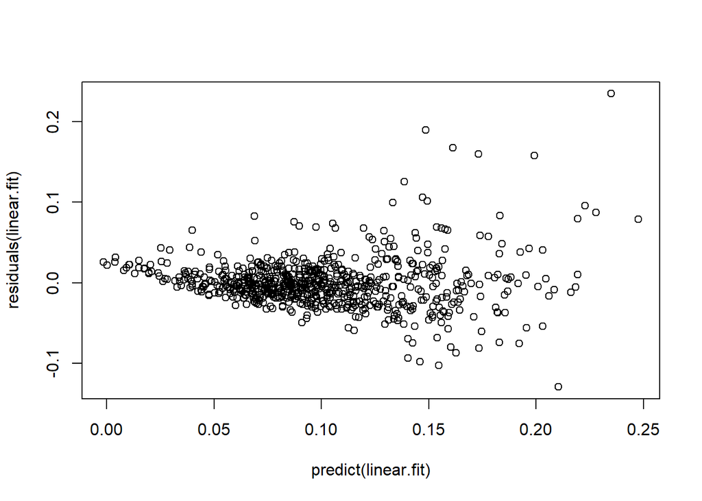

```r
plot(predict(linear.fit), residuals(linear.fit))
```

# 8-b

```r
sort(as.vector(unclass(residuals(linear.fit))))[1:5]
```

```
## [1] -0.12935673 -0.10283231 -0.09834005 -0.09348851 -0.08730486
```

```r
sort(as.vector(unclass(residuals(linear.fit))),decreasing=T)[1:5]
```

```
## [1] 0.2345923 0.1897563 0.1678047 0.1600042 0.1578141
```

```r
match(sort(as.vector(unclass(residuals(linear.fit))))[1:5],as.vector(unclass(residuals(linear.fit))))
```

```
## [1] 266 587 592 581 447
```

```r
match(sort(as.vector(unclass(residuals(linear.fit))),decreasing=T)[1:5],as.vector(unclass(residuals(linear.fit))))
```

```
## [1] 355 363 361 349 356
```

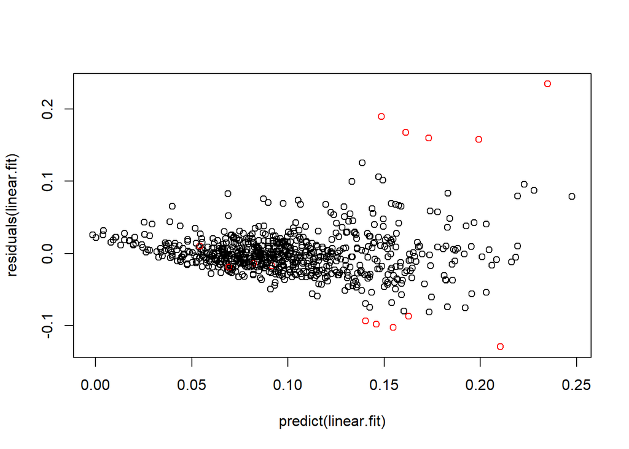

```r
plot(predict(linear.fit),residuals(linear.fit), col =ifelse(newdat2$Name %in% newdat2[c(266,587,592,581,447,355,363,361,349,356),]$Name ,'red','black'))
```

# 9-a

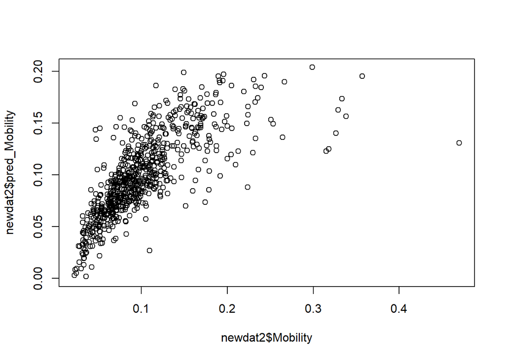

```r
plot(newdat2$Mobility , newdat2$pred_Mobility)
```

실제mobility의값과예측된mobility의값을이용하여scatterplot을그린 결과 선형보다는 비선형에 비슷한 추세를 보이며 서로 어느정도의 관련성을 보여줍니다. 하지만 완전한 선형에 가까운 추세를 보이지는 않기 때문에 예측력이 높다고는 말할수 없습니다. 선형에 가까울수록 예측력이 높다고 할 수 있습니다.

# 9-b

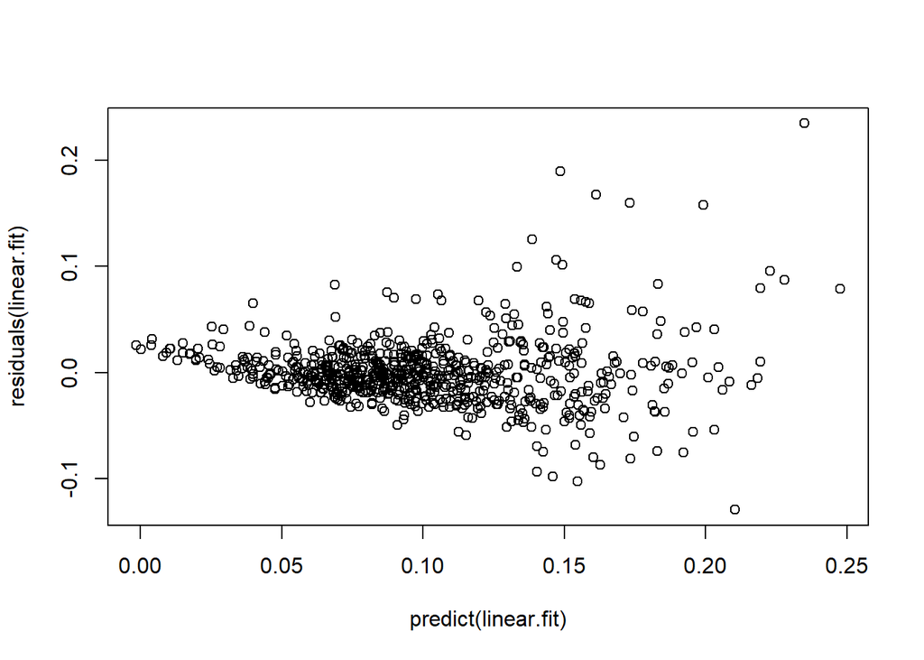

```r
plot(predict(linear.fit), residuals(linear.fit))
```

모형의 잔차와 예측된 mobility의 값을 이용하여 scatter plot을 그린결과 잔차 0을 기준으로 점들이 모여있으나 대략 예측값 0.125를 기준 오른쪽부터 잔차들이 퍼지는 경향을 보이는데 잔차의 등분산성 가정을 어느정도 위배하는 패턴을 보입니다. 선형추세는 보이지 않으며 0.0을기준으로 변동성이 적도록 모여있는것이 가장 이상적이라고 할 수 있습니다.

# 10-a

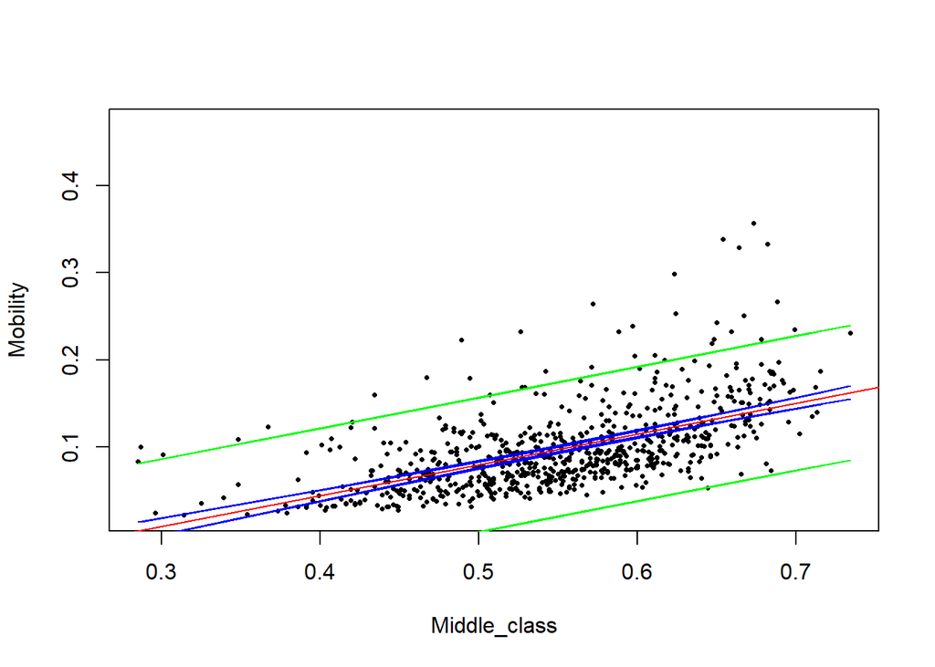

```r
fit.frac = lm(Mobility ~ Middle_class , data = dat)
confidence_interval = predict(fit.frac, newdata = dat , interval = 'confidence'  ,level = 0.95)
prediction_interval = predict(fit.frac, newdata = dat , interval = 'prediction',level = 0.95)

plot(Mobility ~ Middle_class, data = dat, pch = 16, cex = 0.5)
abline(fit.frac , col = 'red')
lines(dat$Middle_class , confidence_interval[,2],col='blue')
lines(dat$Middle_class , confidence_interval[,3],col='blue')
lines(dat$Middle_class , prediction_interval[,2],col='green')
lines(dat$Middle_class , prediction_interval[,3],col='green')
```

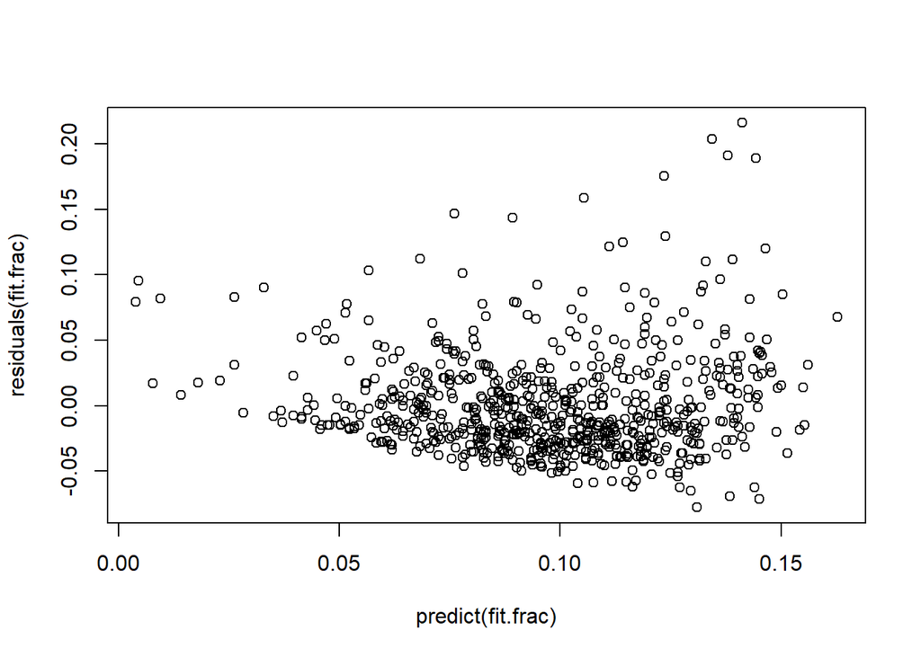

```r
plot( predict(fit.frac)  , residuals(fit.frac))
```

# 10-b

```r
#confidence interval
library(boot)
boot.coef <- function(data, indices){
  data <- data[indices,]
  mod <- lm(Mobility ~ Middle_class, data = data)
            coefficients(mod)[-1]
}

boot.out <- boot(dat, boot.coef, 500)
boot.out
```

```
##
## ORDINARY NONPARAMETRIC BOOTSTRAP
##
##
## Call:
## boot(data = dat, statistic = boot.coef, R = 500)
##
##
## Bootstrap Statistics :
##      original      bias    std. error
## t1* 0.3538504 0.001259589  0.02247897
```

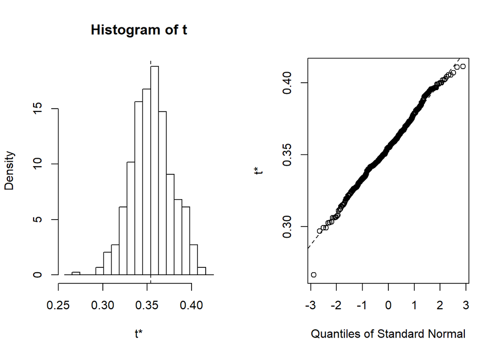

```r
plot(boot.out)
```

```r
boot.ci(boot.out, index = 1, type =c("norm"))
```

```
## BOOTSTRAP CONFIDENCE INTERVAL CALCULATIONS
## Based on 500 bootstrap replicates
##
## CALL :
## boot.ci(boot.out = boot.out, type = c("norm"), index = 1)
##
## Intervals :
## Level      Normal
## 95%   ( 0.3085,  0.3966 )
## Calculations and Intervals on Original Scale
```

```r
#prediction interval
boot.pred <- function(data, indices){
  data <- data[indices,]
  mod <- lm(Mobility ~ Middle_class, data = data)
  predict(mod,data)
}

boot.out2 <- boot(dat, boot.pred, 500)
boot.out2
```

[output not shown]

[output cut: 696 more lines]

[output not shown]

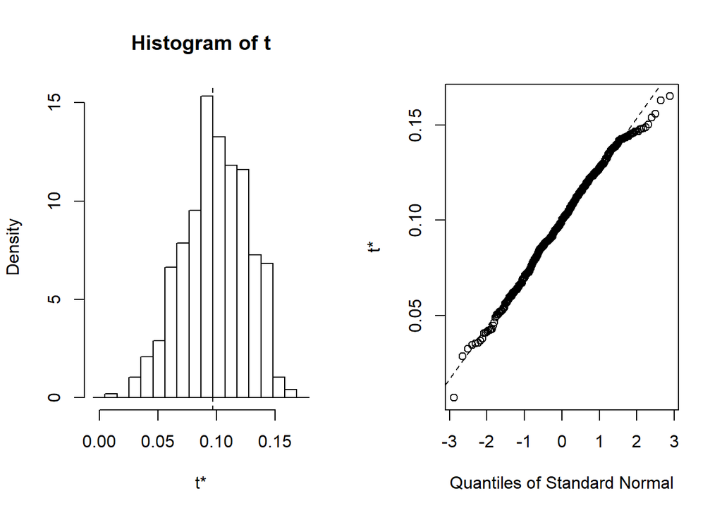

```r
plot(boot.out2)
```

```r
boot.ci(boot.out2, index = 1, type =c("norm"))
```

```
## BOOTSTRAP CONFIDENCE INTERVAL CALCULATIONS
## Based on 472 bootstrap replicates
##
## CALL :
## boot.ci(boot.out = boot.out2, type = c("norm"), index = 1)
##
## Intervals :
## Level      Normal
## 95%   ( 0.0410,  0.1486 )
## Calculations and Intervals on Original Scale
```

# 10-c

```r
library(dplyr)
dat_4 <- dat[complete.cases(dat[ , c("Middle_class")]), ]
sum(is.na(dat_4$Middle_class))
```

```
## [1] 0
```

```r
x = dat_4$Middle_class
y = dat_4$Mobility

splinemod1 = smooth.spline(x,y,cv = FALSE)
splinemod1$df
```

```
## [1] 5.027526
```

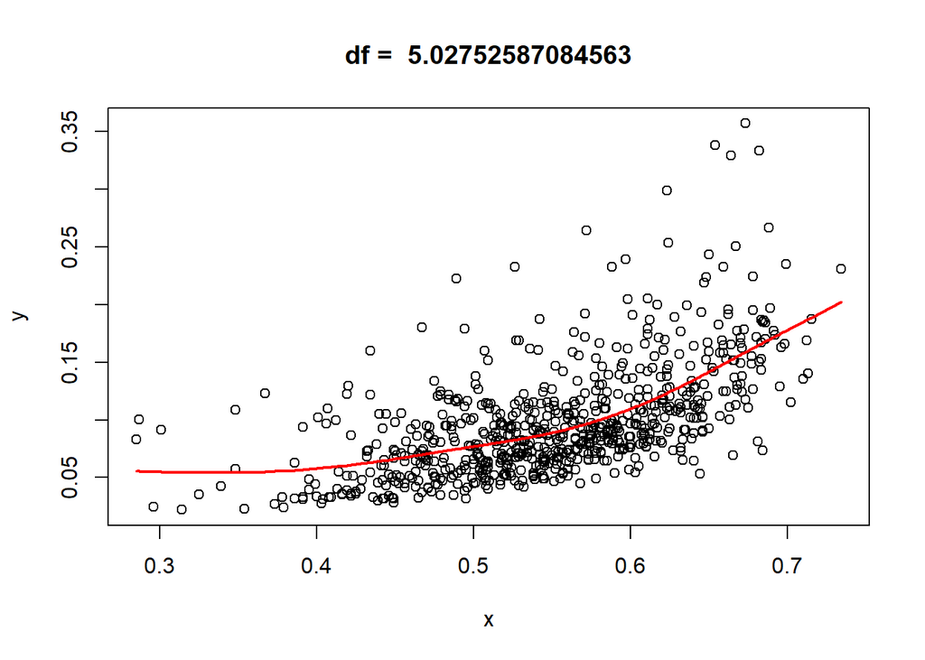

```r
plot(x, y, main = paste("df = ",splinemod1$df))
lines(splinemod1$x,splinemod1$y, col = 'red', lwd= 2)
```

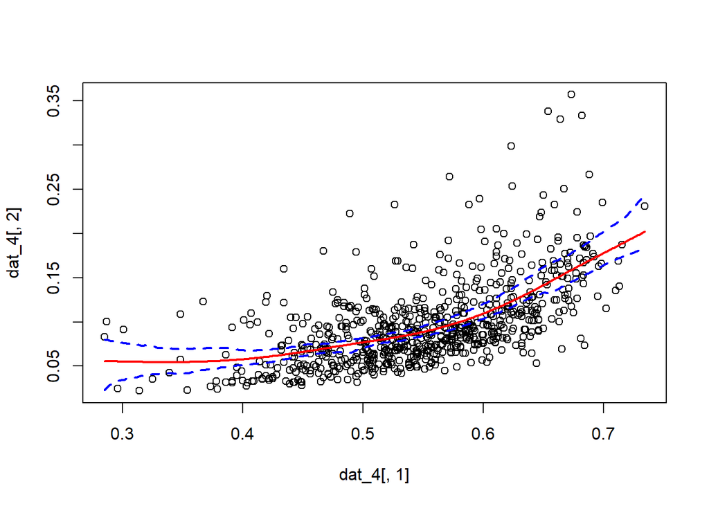

```r
resampler <- function(data) {
  n <- nrow(data)
  resample.rows <- sample(1:n,size=n,replace=TRUE)
  return(data[resample.rows,])
}

spline.estimator <- function(data,m=300) {
  fit <- smooth.spline(x=data[,1],y=data[,2],cv=TRUE)
  eval.grid <- seq(from=min(data[,1]),to=max(data[,1]),length.out=m)
  return(predict(fit,x=eval.grid)$y)
}

spline.cis <- function(data,B,alpha=0.05,m=300) {
  spline.main <- spline.estimator(data,m=m)
  spline.boots <- replicate(B,spline.estimator(resampler(data),m=m))
  cis.lower <- 2*spline.main - apply(spline.boots,1,quantile,probs=1-alpha/2)
  cis.upper <- 2*spline.main - apply(spline.boots,1,quantile,probs=alpha/2)
  return(list(main.curve=spline.main,lower.ci=cis.lower,upper.ci=cis.upper,
              x=seq(from=min(data[,1]),to=max(data[,1]),length.out=m)))
}


dat_4 = dat_4 %>% select(Middle_class,Mobility)


sp.cis <- spline.cis(dat_4, B=1000,alpha=0.05)
plot(dat_4[,1],dat_4[,2])
lines(x=sp.cis$x,y=sp.cis$main.curve, col = 'red', lwd = 2)
lines(x=sp.cis$x,y=sp.cis$lower.ci, lty=2, col = 'blue', lwd = 2)
lines(x=sp.cis$x,y=sp.cis$upper.ci, lty=2, col = 'blue', lwd = 2)
```

# 10-d

그래프를 보면 비선형적인 추세를 보이므로 선형회귀분석 보다는 smoothing spline을 이용한 비모수적 회귀분석이 적합합니다.